# Selvstudie_1

Jonathan Strandberg

11 mar 2019

## Selvstudieopgavesæt 1

Nedenstående opgave arbejdes der med ved første selvstudie-kursusgang. Data til opgaven er prisen i dollars pr. tønde (42 gallon) “West-Texas Intermediate Crude Oil (WTI)”. Priserne foreligger som månedsdata fra Januar 1986 til Juni 2013, i alt 330 observationer. Datasættet er i filen ‘olie.RData’ som kan indlæses med funktionen load(). Til identifikationen og estimationen nedenfor bruges data op til december 2012. De sidste 6 måneder, fra januar 2013 til juni 2013 reserveres til out-of-sample forecasting (Hint: Brug funktionen window() til at opdele datasættet)

# Opgave

Identificér, estimér og prædiktér (forecast) ARMA modeller for logaritmen til olieprisen (her kaldes denne variabel $x_t$)

1. I det følgende betragtes som nævnt de 324 første observationer, altså data til og med december 2012. Plot og beskriv kort log prisen af olie i perioden. Kommentér på særligt usædvanlige egenskaber ved data. Beregn, plot og fortolk korrelogrmmet for log-olieprisen, samt korrelogrammet for første-differensen af log-olieprisen.

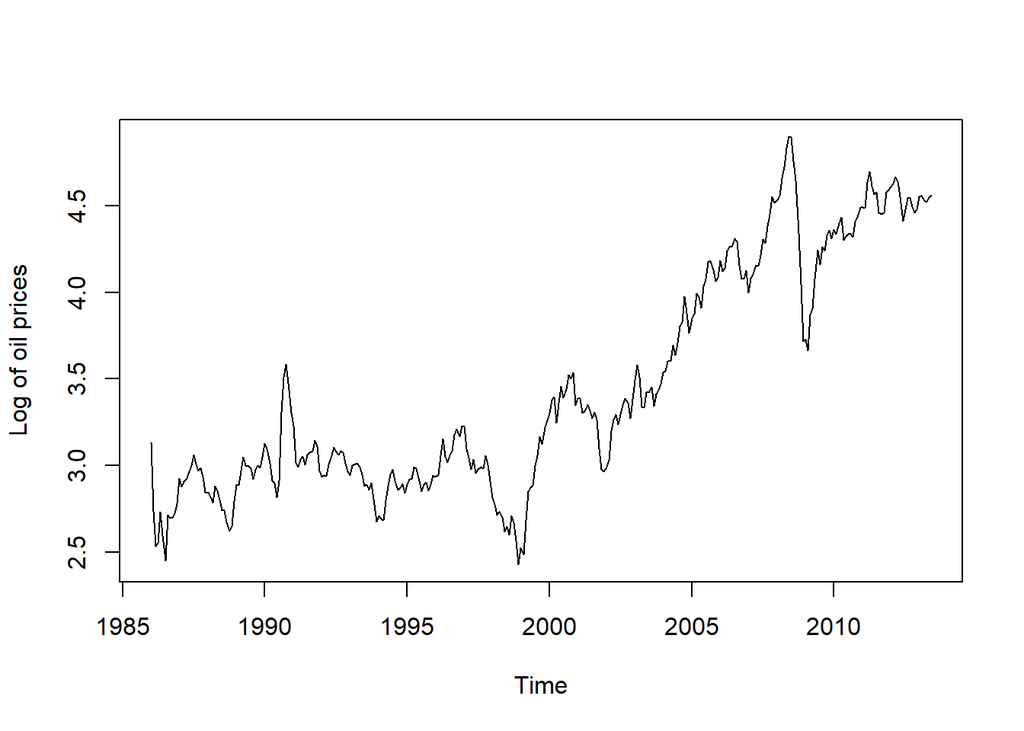

```r
# Indlæser oliedata
load("olie.Rdata")
loil <- log(olie)

# Plotter log-oil
plot(loil , ylab = "Log of oil prices")
```

Ses at der forekommer en stærk opadgående trend med spikes

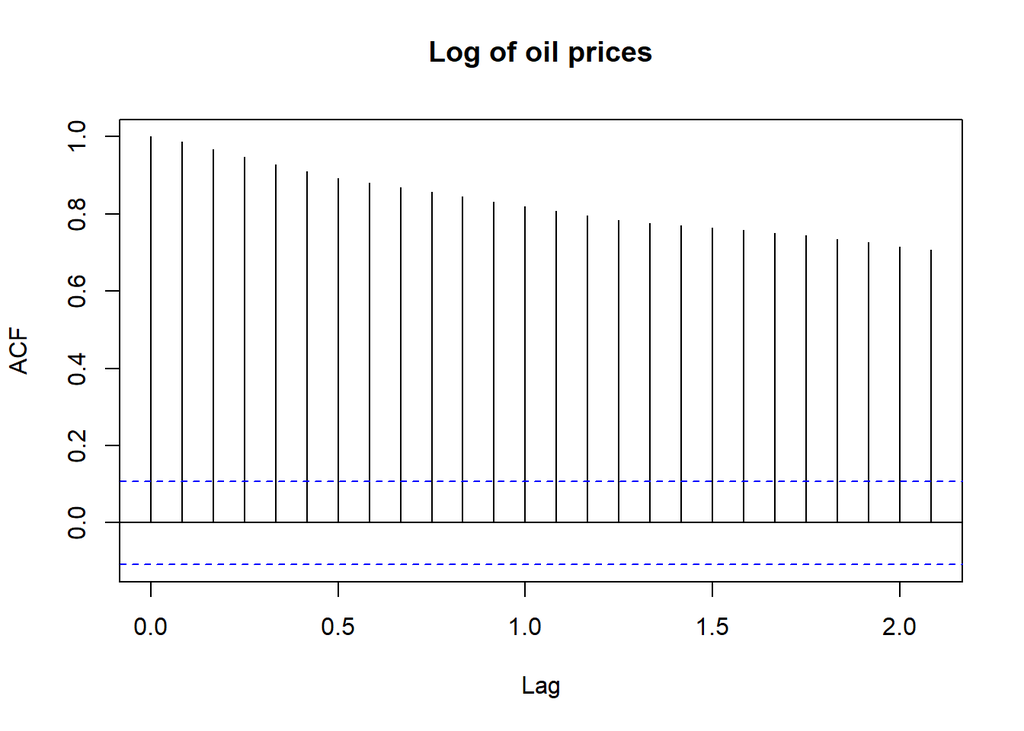

```r
# Plotter acf for 'loil
acf(loil , main = "Log of oil prices")
```

Ses at ACF’en ikke aftager eksponentielt, og tidsrækken ser altså ikke stationær ud.

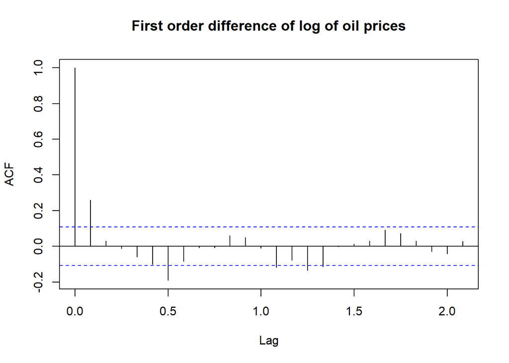

```r
# Plotter acf for første-differensen af 'loil'
acf(diff(loil) , main = "First order difference of log of oil prices")
```

Efter der er blevet taget differens ses det at ACF’en aftager eksponentielt, og tidsrækken ser stationær ud.

2. Estimér en AR(1) model for log-olieprisen på to forskellige måder. Estimér først autoregressionen

$$x_t = \alpha + \phi x_{t-1} + w_t$$

og estimér dernæste den middelværdi-justerede model

$$x_t - \mu = \phi (x_{t-1} - \mu) + w_t$$

Hvad fortæller estimatet på $\phi$ om “stabiliteten” (stationariteten) af modellen?

```r
# Laver x_t og x_{t-1}
start <- c(1986,1)
end   <- c(2012,12)

xins <- window(loil , start = start , end = end)
n <- length(xins)

x      <- xins[2:n]
xlag   <- xins[1:(n-1)]
xdm    <- x - mean(x)
xlagdm <- xlag - mean(xlag)

ar1.coef        <- lm(x ~ xlag)$coefficients
ar1.demean.coef <- lm(xdm ~ xlagdm)$coefficients

df <- data.frame(x = ar1.coef , xdemean = ar1.demean.coef)
rownames(df) <- c("Alpha" , "Phi") ; print(df)
```

```
##                x      xdemean
## Alpha 0.02285715 3.459370e-16
## Phi   0.99454695 9.945469e-01
```

Det ses at når vi har ‘demeanet’ estimeres skæringen til at være tæt på 0

I det resterende sammenlignes to forskellige tranformationer til at gøre tidsrækken stationær, og i kan overveje og vurdére, hvilken transformation der bedst gør tidsrækken stationær.

3. Beregn, plot og vurdér ACF og PACF for første-differensen af log-olieprisen

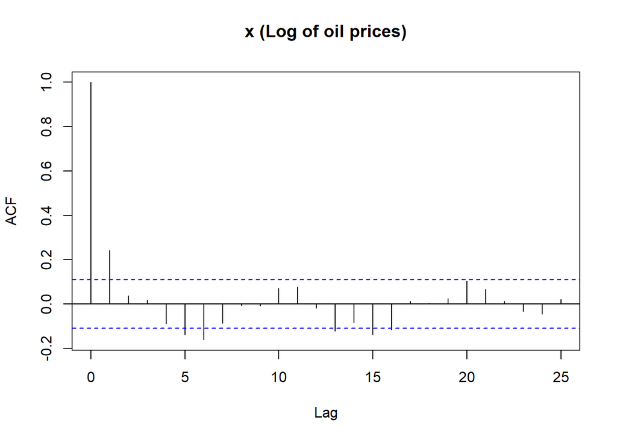

```r
xd    <- diff(x)
xlagd <- diff(xlag)

# Plotter ACF og PACF for første-differensen af log-olieprisen
acf(xd , main = "x (Log of oil prices)")
```

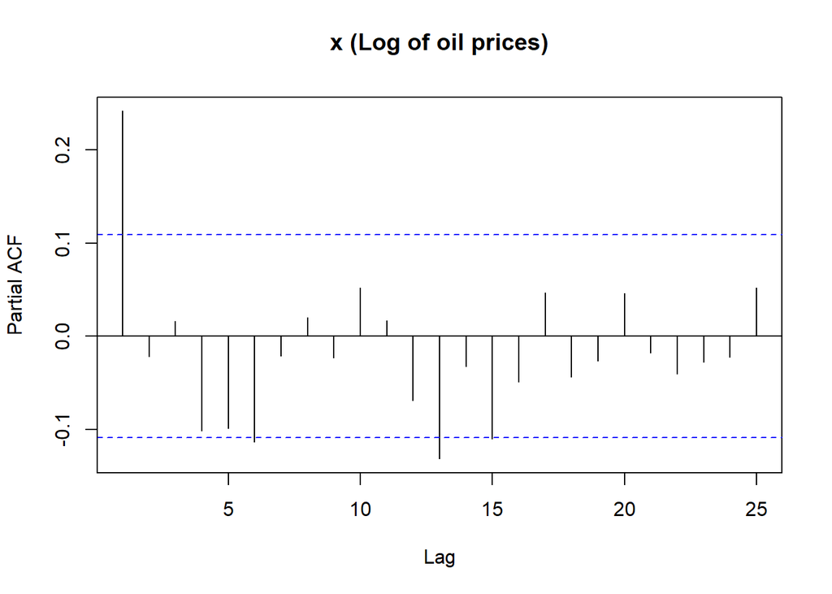

```r
pacf(xd , main = "x (Log of oil prices)")
```

4. *Detrend* log-olieprisen ved at beregne residualerne fra en regression af log-olieprisen på en konstant og en lineær trend. Disse residualer kan vi kalde den *detrendede* log-oliepris, dvs. log-olieprisen når trenden er fjernet

```r
dtx <- lm(x  ~ xlag)$residuals
```

5. 1. For den *detrendede* log-oliepris og (2) dernæst for første-differensen af log-olieprisen, beregn AIC (og eventuelt BIC) for alle ARMA$(p,q)$ modeller med $p=0,1,2,3,4$ og $q=0,1,2,3,4$. Hvilke modeller vælges ud fra disse informationskriterier?

```r
df <- data.frame(q0 = numeric(5) ,
                 q1 = numeric(5) ,
                 q2 = numeric(5) ,
                 q3 = numeric(5) ,
                 q4 = numeric(5))
rownames(df) <- c("p0" , "p1", "p2" , "p3" , "p4")

for(p in 0:4){
  for(q in 0:4){
    armamod <- Arima(dtx , order = c(p,0,q))
    df[p+1,q+1] <- AIC(armamod)
  }
}
print(df)
```

```
##           q0        q1        q2        q3        q4
## p0 -656.7023 -678.9845 -677.6248 -675.8057 -674.1987
## p1 -679.3884 -677.6775 -675.6772 -678.6267 -678.2561
## p2 -677.6931 -675.6773 -673.6776 -680.8850 -670.7778
## p3 -675.7392 -680.2625 -675.8628 -677.7803 -673.4036
## p4 -675.0618 -672.6939 -675.2815 -681.7647 -678.3634
```